**Fisher Discriminant Analysis**

|  | by Prof. Seungchul Lee iSystems Design Lab http://isystems.unist.ac.kr/ UNIST |
| --- | --- |

Table of Contents

# 1. Dimensionality Reduction with Label

- Dimensionality reduction with label information (when the ultimate goal is classification/regression)
- PCA ignores label information even if it is available
  - Only chooses directions of maximum variance
- Fisher Discriminant Analysis (FDA) takes into account the label information
  - It is also called Linear Discriminant Analysis (LDA)
- FDA/LDA projects data while preserving class separation
  - Examples from same class are put closely together by the projection
  - Examples from different classes are placed far apart by the projection

# 2. Projection onto Line $\omega$

- Linear regression projects each data point
  - assume zero mean, otherwise $x \leftarrow x - \bar{x}$
  - $\omega_0 = 0$

$$ \hat{y} = \langle \omega,x\rangle = \omega^Tx = \omega_1x_1 + \omega_2x_2$$

- Dimension reduction

$$x = \begin{bmatrix}x_1 \\ x_2 \end{bmatrix} \rightarrow \hat y \; (\text{scalar})$$

- Each data point $x = \begin{bmatrix}x_1 \\ x_2 \end{bmatrix}$ is projected onto $\omega$ (projected length on $\omega$ direction)
- For a given $\omega$, distribution of the projected points $\{ \hat y^{(1)}, \cdots, \hat y^{(m)} \}$ is specified.

  **Question: Which $\omega$ is better for classification?**

[figure not shown]

| $$\text{Class }C_0$$ | $$\text{Class }C_1$$ |
| --- | --- |
| $\quad$ sample mean $\mu_0$ $\quad$ sample variance $S_0$ $\qquad \mu _0 = \frac{1}{n_0} \sum\limits_{ x^{(i)} \in C_0}^{n_0}x^{(i)}$ $\qquad S_0 = \frac{1}{n_0 - 1} \sum\limits_{ x^{(i)} \in C_0}^{n_… | $\quad$ sample mean $\mu_1$ $\quad$ sample variance $S_1$ $\qquad \mu _1 = \frac{1}{n_1} \sum\limits_{ x^{(i)} \in C_1}^{n_1}x^{(i)}$ $\qquad S_1 = \frac{1}{n_1 - 1} \sum\limits_{ x^{(i)} \in C_1}^{n_… |
| $\quad$ Projected space $\qquad E\,[ \hat y \mid x \in C_0 ] = \mu_0^T\omega$ $\qquad \text{var}\,[\hat y \mid x \in C_0 ] = \omega^TS_0\omega$ | $\quad$ Projected space $\qquad E\,[ \hat y \mid x \in C_1 ] = \mu_1^T\omega$ $\qquad \text{var}\,[\hat y \mid x \in C_1 ] = \omega^TS_1\omega$ |

# 3. Fisher Discriminant Analysis

- Find $\omega$ so that when projected onto $\omega$,
  - the classes are maximally separated (maximize distance between classes)
  - Each class is tight (minimize variance of each class)

$$\max_\omega \frac{(\text{seperation of projected means})^2}{\text{sum of within class variances}}$$

$$ \implies \max_\omega \frac {\big(\mu_0^T\omega - \mu_1^T\omega \big)^2}{n_0\omega^TS_0\omega + n_1\omega^TS_1\omega}$$

[figure not shown]

$$\omega = \text{arg}\max_\omega \bigg\{ \frac{\big((\mu_0^T - \mu_1^T)\omega\big)^2}{n_0\omega^TS_0\omega + n_1\omega^TS_1\omega} \bigg \}$$

$$J(\omega) = \frac {\big((\mu_0^T - \mu_1^T)\omega\big)^2}{\omega^T(n_0S_0 + n_1S_1)\omega} = \frac {(m^T\omega)^2}{\omega^T\Sigma \omega}$$

$ $

| $ m \equiv \mu_0 - \mu_1$ |  |
| --- | --- |
| $ \Sigma \equiv n_0S_0 + n_1S_1 = R^TR$ | We can always write $\Sigma$ like this, where $R$ is a "square root" matrix |
| $u \equiv R\omega \rightarrow \omega = R^{-1}u$ | Using $R$, change the coordinate systems from $\omega$ to $u$ |

$$J(u) = \frac {\big( m^TR^{-1}u\big)^2}{\omega^TR^TR\omega} = \frac {\bigg( \big(R^{-T}m \big)^Tu\bigg)^2}{u^Tu}= \bigg( \left(R^{-T}m \right)^T \frac{u}{\parallel u \parallel} \bigg)^2$$

$$J(u) = \bigg( \left(R^{(-T)}m \right)^T \frac{u}{\lVert u \rVert} \bigg)^2 \; \text{is maximum when} \; u = a\,R^{-T}m$$

- Why?
  - Dot product of a unit vector and another vector is maximum when the two have the same direction.

$$\begin{align*} u &= aR^{-T}m = aR^{-T}(\mu_0 - \mu_1)\\ \omega &= R^{-1}u = aR^{-1}R^{-T}(\mu_0 - \mu_1) = a\big(R^TR\big)^{-1}(\mu_0 - \mu_1) = a\Sigma^{-1}(\mu_0 - \mu_1) \\ \\ \therefore \; \omega &= a(n_0S_0 + n_1S_1)^{-1}(\mu_0 - \mu_1) \end{align*}$$

# 4. Python Code

```python
import numpy as np
import matplotlib.pyplot as plt

% matplotlib inline
```

```python
#training data set generation

n0 = 200
n1 = 200

mu = [0, 0]
sigma = [[0.9, -0.4],
         [-0.4, 0.3]]

x0 = np.random.multivariate_normal([2.5,2.5], sigma, n0).T        # data in class 0
x1 = np.random.multivariate_normal([1,1], sigma, n1).T            # data in class 0

print(x0.shape)

x0 = np.asmatrix(x0)
x1 = np.asmatrix(x1)
```

```
(2, 200)
```

```python
mu0 = np.mean(x0, axis=1)
mu1 = np.mean(x1, axis=1)

S0 = 1/(n0-1) * (x0-mu0)*(x0-mu0).T
S1 = 1/(n1-1) * (x1-mu1)*(x1-mu1).T

w = (n0*S0 + n1*S1).I * (mu0-mu1)
print(w)
```

```
[[ 0.02432795]
 [ 0.04290126]]
```

**Projection line and histogram**

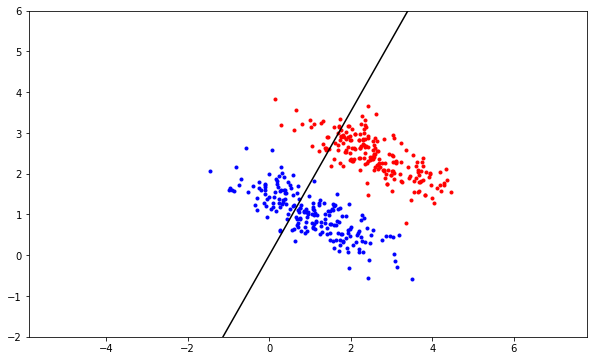

```python
plt.figure(figsize = (10, 6))
plt.plot(x0[0,:],x0[1,:],'r.')
plt.plot(x1[0,:],x1[1,:],'b.')

xp = np.arange(-4, 6, 0.1)
yp = w[1,0]/w[0,0]  * xp
plt.plot(xp, yp, 'k')
plt.axis('equal')
plt.ylim([-2, 6])
plt.show()
```

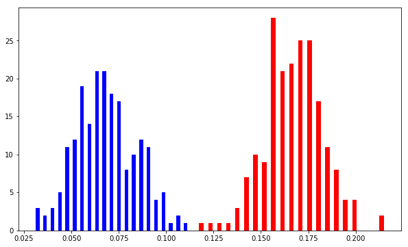

```python
y1 = x0.T*w
y2 = x1.T*w

plt.figure(figsize = (10, 6))
plt.hist(y1, 21, color='r', rwidth=0.5)
plt.hist(y2, 21, color='b', rwidth=0.5)
plt.show()
```

**different $\omega$ (x axis)**

```python
w = np.array([[1],[0]])
w = np.asmatrix(w)
```

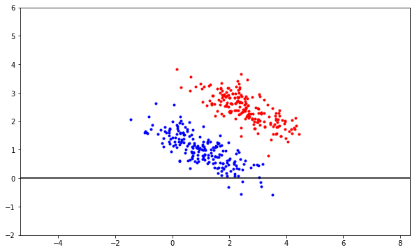

```python
plt.figure(figsize = (10, 6))
plt.plot(x0[0,:],x0[1,:],'r.')
plt.plot(x1[0,:],x1[1,:],'b.')
plt.axhline(0, color='k')
plt.axis('equal')
plt.ylim([-2, 6])
plt.show()
```

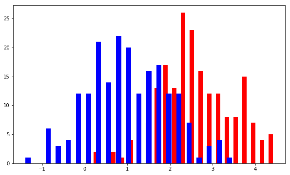

```python
y1 = x0.T*w
y2 = x1.T*w

plt.figure(figsize = (10, 6))
plt.hist(y1, 21, color='r', rwidth=0.5)
plt.hist(y2, 21, color='b', rwidth=0.5)
plt.show()
```

**different $\omega$ (y axis)**

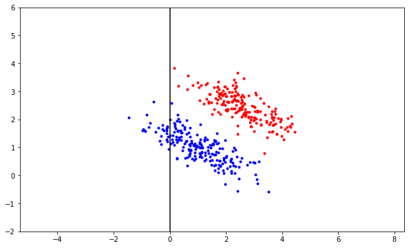

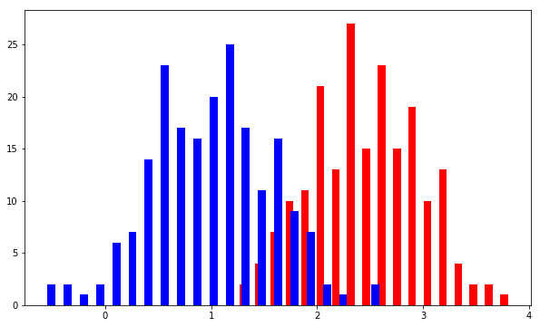

```python
w = np.array([[0],[1]])
w = np.asmatrix(w)

plt.figure(figsize = (10, 6))
plt.plot(x0[0,:],x0[1,:],'r.')
plt.plot(x1[0,:],x1[1,:],'b.')
plt.axvline(0, color='k')
plt.axis('equal')
plt.ylim([-2, 6])
plt.show()

y1 = x0.T*w
y2 = x1.T*w

plt.figure(figsize = (10, 6))
plt.hist(y1, 21, color='r', rwidth=0.5)
plt.hist(y2, 21, color='b', rwidth=0.5)
plt.show()
```